# Raport - projekt zaliczeniowy nr 2

Zofia Gruba

2022-06-04

## Eksploracja danych

Dane treningowe zawierają **3794** obserwacji. Jedna zmienna objaśniana i **9000** zmiennych objaśniających. W zbiorze testowym jest **670** obserwacji i **9000** zmienych. Każda zmienna jest typu *numeric* i dane są kompletne.

Badając empiryczny rozkład zmiennej objaśnianej otrzymuję, że najmiejsza wartość jaką przyjmuje to **0**, największa zaś to **2.8647**. Podstawowe statystyki:

- średnia: **1.1229**
- wariancja: **0.6006**
- mediana: **1.3865**
- dominanta: **0**

Poniżej przedstawiam wykresy opisujące rozkład tej zmiennej:

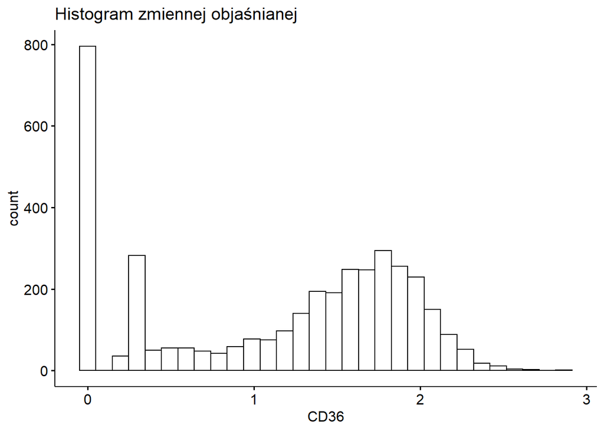

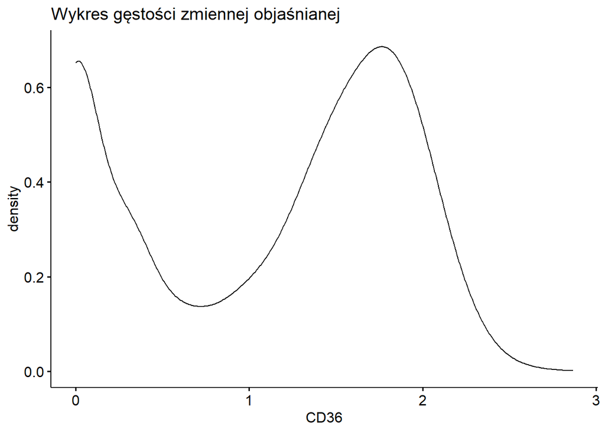

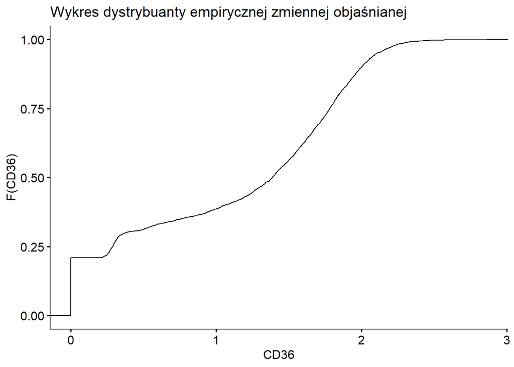

### Mapa ciepła korelacji 250 zmiennych najbardziej skorelowanych z zmienną objaśnianą

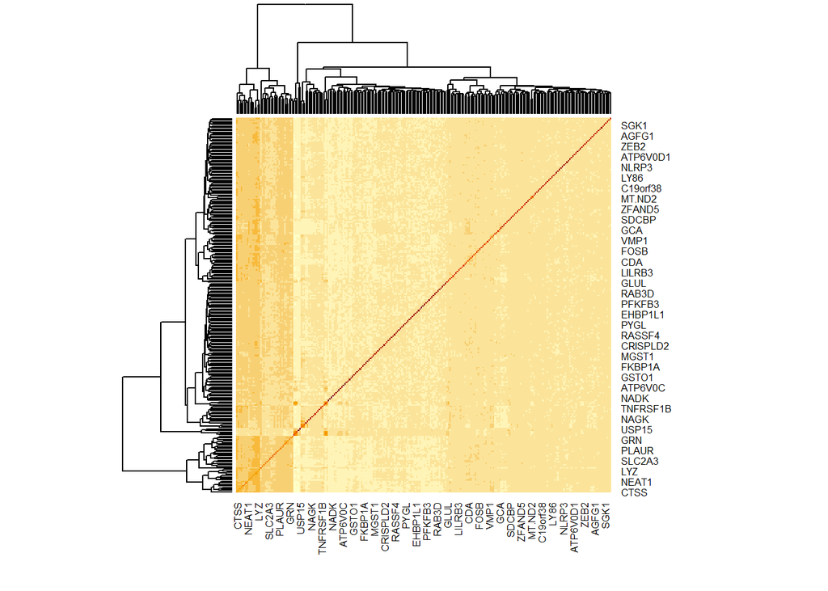

## ElasticNet

Model ElasticNet to połączenie dwóch modeli: regresji grzbietowej i metody Lasso. Estymujemy współczynniki regresji dla ustalonych hiperparametrów $\lambda$ i $\alpha$.

Wyrażenie, które minimalizujemy dla regresji grzbietowej:
$$RSS + \lambda\||\hat{\beta}||_2^2$$

Wyrażenie, które mimalizujemy dla metody Lasso:
$$RSS + \lambda||\hat{\beta}||_1$$

Tak jak w regresji grzbietowej i Lasso w ElasticNet również mamy parametr sterujący $\lambda$. Dla $\lambda = 0$ mamy po prostu metodę najmniejszych kwadratów, nastomiast gdy $\lambda \rightarrow \infty$ współczynniki regresji maleją do zera. Połączenie tych dwóch metod w ElasticNet polega kombinacji wypukłej kar ściągających z parametrem $\alpha$.

Wyrażenie, które mimalizujemy dla ElasticNet:
$$\frac{RSS}{2N} +
\lambda(\frac{1-\alpha}{2}||\hat{\beta}||_2^2 +
\alpha||\hat{\beta}||_1)$$
zgodnie z *glmnet.stanford.edu*.

Dla parametru $\alpha = 0$ mamy regresję grzbietową, a dla $\alpha = 1$ lasso.

Stosując 5-krotną walidację krzyżową dla następującej siatki:

$$\alpha \in \{0, 0.02, 0.04, ..., 0.96,
0.98, 1 \}$$
$$\lambda \in \{0.01,
0.12, 0.23, 0.34, 0.45, 0.56, 0.67, 0.78, 0.89, 1 \}$$
otrzymałam najmniejszy błąd walidacji dla $\alpha = 0.02$ i $\lambda = 0.45$.

Walidacja krzyżowa dzieli zbiór treningowy na **5** części po ok.**760** obserwacji. Przyjęłam **k=5** zgodnie z sugestią przedstawioną na wykładzie. Jest to kompromis między czasem trenowania a elastycznością modelu. Dla każdego kroku walidacji dostajemy w proporcji **4:1** zbiór treningowy na którym treningowym trenujemy model, walidacyjny na którym szacujemy błąd.

Dla modelu z wybranymi parametrami wyliczam:

- błąd treningowy: **0.2866**
- błąd walidacyjny: **0.3366**

## Lasy losowe

Mój model lasów losowych trenuję na następującej siatce parametrów:

$$mtry \in \{100, 300, 500 \}$$
$$ntrees \in \{100,500,750 \}$$
$$max.depth \in \{0,25,50\}$$

Porównanie wyników dla siatki:

| Model | mtry | ntree | max.depth | RMSE |
| --- | --- | --- | --- | --- |
| 1 | 500 | 100 | inf | 0.3244 |
| 2 | 500 | 500 | inf | 0.3222 |
| 3 | 500 | 750 | inf | 0.3217 |
| 4 | 500 | 100 | 25 | 0.3238 |
| 5 | 500 | 500 | 25 | 0.3217 |
| 6 | 500 | 750 | 25 | 0.3212 |
| 7 | 500 | 100 | 50 | 0.3244 |
| 8 | 500 | 500 | 50 | 0.3221 |
| 9 | 500 | 750 | 50 | 0.3217 |

Najlepszy model dla: mtry = **500**, ntree = **750**, max depth = **25**. Ten model ma najniższe RMSE, a chcemy przez nie oszacować błąd testowy.

Porównanie ElasticNet, lasów losowych i modelu przypisującego średnią:

| Model | Fold1 | Fold2 | Fold3 | Fold4 | Fold5 | Average |
| --- | --- | --- | --- | --- | --- | --- |
| ElasticNet | 0.3303 | 0.3369 | 0.3328 | 0.3390 | 0.3438 | 0.3366 |
| Lasy losowe | 0.3136 | 0.3267 | 0.3168 | 0.3222 | 0.3268 | 0.3212 |
| Referencyjny | 0.7692 | 0.7799 | 0.7759 | 0.7790 | 0.7704 | 0.7749 |

Najlepszym modelem wydaje się być model lasów losowych. Daje on najniższy błąd na każdym z foldów oraz najniższy ostateczny błąd walidacyjny.

## Predykcja na zbiorze testowym

Jako model do predykcji wybrałam model QRF, czyli Quantile Regression Forests. Ten model dobrze sprawdza się w szczególności do danych wysokowymiarowych. Zgodnie z (*Meinshausen, 2006*) przedziały predykcji obejmują nowe obserwacje z dużym prawdopodobieństwem. Metoda wyłapuje obserwacje odstające. Przedziały predykcji dobrze odzwierciedlają zmienność danych, co czyni je bardzo dokładne, jeśli chodzi o przewidywanie.

Model QRF jest oparty na modelu lasów losowych i warunkowej wartości oczekiwanej zmiennej objaśnianej, polega na estymowaniu kwantyli warunkowych.

Model wybrałam na podstwie wyników na platformie *Kaggle*. Testowałam różne wariacje na temat lasów losowych z pakietów *caret*. Wcześniejsze predykcje pochodziły od modeli RRF (Regularized Random Forest) i RF (z pakietu *ranger*) z poprzedniego zadania. RMSE dla RRF utrzymywał się na poziomie ok. **0.176** (dla preprocesowania nie było znaczących zmian), natomiast dla RF ok. **0.185**. Dopiero QRF dał wynik poniżej **0.15**, który w rankingu wydał się być konkurencyjny.

Ostateczna predykcja QRF w *Kaggle* dała RMSE równe **0.148**. Dla 5-krotnej walidacji krzyżowej i następujących wartości hiperparametrów:

- mtry = **1200**
- nodesize = **5**
- ntrees = **500**